# Languages in Estonian Newspaper collection (before 1918)

Antonina Martynenko

6/7/2022

#### Summary

This blog post explores languages inside the “Russian” part of DIGAR Collection. The metadata for newspapers issued before 1918 shows large number of Russian-language newspapers, however both the page and section-level data provide an evidence that the newspapers were not monolingual and some part of the collection labeled as Russian is in fact in German, Estonian and Latvian. The analysis provided aims to show how the history of Russification in Estonia is reflected in digitized newspaper pages and how metadata issues may probably influence OCR quality.

According to the metadata, a large part of the newspapers issued during the imperial period (before 1917) is marked as Russian-language ones. If counted in pages, there should be more than 120 thousands pages labeled as pages in “Russian” (`Language` column), with the following total distribution of pages over time:

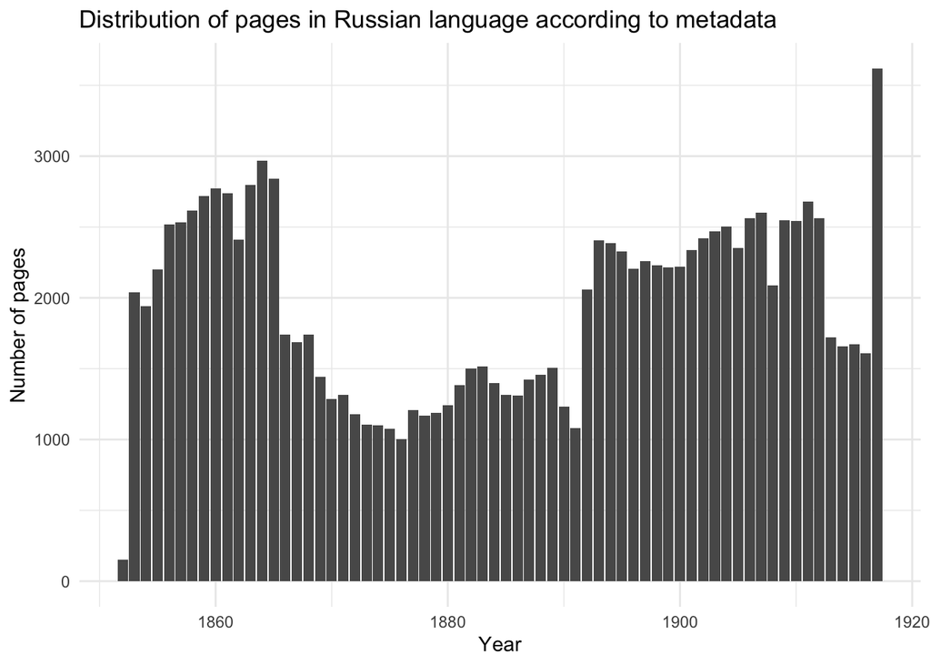

After retrieving these pages’ texts, it is obvious that at least partly the title-level language metadata is wrong: e.g. the earliest “Russian” pages in the collection dated 1852 are mostly in German.

| text |
| --- |
| 1842 sich außer der Stadtbefehlshaberschaft auch auf die Stadt Rostow (im Jekaterinoslawschen Gouvernement) erstreck. Der Procureur d’er StadtbefeHlstzaberAchOßk. d) I n Taganrog. Im Ressort des Minis… |
| 0тд елъ второй. Zweite Abtheilung. Часть оффициальная. Officieller Theil. Durch Allerhöchsten Tagesbefehl im CimlRessort vom 19» October 1852, Nr. 269, sind bestätigt: Als Rigascher Ordnungsrichter Ma… |
| Md. XIV. Ust. über Pässe und Läuflinqe Art. 589. Nr. 82. ’ Diebstahl. Publication der Strafbestimmungen für denselben. Nr. 85 u. 86, lettisch und ehstnisch Nr. 91 u. 92. Dienstboten-Bücher Nr. 54, let… |

### Language detection

To make a new rough language detection an R-package `textcat` was used. It takes a text as a string and calculates its average score to detect a language, so as a result a new metadata column will have one most probable language detected for each page.  
A better solution may be found here, since many pages will probably have several languages combined at one page. However, this package is still applicable for a rough estimation of major languages proportion in these pages.

```
##
##  estonian    german   latvian   russian ukrainian
##       699     49328       128     74815      3102
```

However, even the “Ukrainian” pages should be excluded from the analysis, since these pages are in fact badly OCR-ed pages in Cyrillic script. Randomly selected chunks shows these pages are mostly in Russian, but being unable to check them all I filtered these pages as highly messy and unpredictable. This result is very disappointing showing not a language diversity but issues inside tools trained on major languages and giving an imperialistic assumption on Ukrainian being (on the character level) a messy Cyrillic which is not Russian (see an example below).

| text |
| --- |
| 4 Р е в е л ь о x I н fl I :i lotis. M 259 О К Ъ Я В Л К П I я. отъ эстляндской КАЗЕННОЙ ПАЛАТЫ ОБЪЯВЛЕНИЕ. Уъзлнын Казначейства Везенбергское. Вейсенштейнское и Гапсальское, Эстляндской губернш, буду… |
| Ui urm paifUiitMB, t. Рмш, 87-y, urym 1900 ff. Пив*11я1Йи\|ц ■—ууп. ТамграфЫ (umt;.r«aib«aia Uua.-«iB’. 4 Р в в е ль oxl а И tat о*! а*. «19: ОБЪЯВЛЕН! Я. Упраие ul’ BajTlBcKol и Вомм-Тижгко! жмЪшъиъ … |
| Рмми F tr« И »»HlUi Б Ъ М R .1 В В I Г М 246. •а j О .•га ИЯИИНДЙЙИКЯКЙКиц ДДЙЙЙЙЙЙ Д и м*£Д Я KjlH И Н Д Д Н Н Н Н И И Н Ц U К\|Д Ц\|Ц ИДИ Н.ЙДЙ ДЙ ДЙЙЙЙ я ОТКРЫТА ПОДПИСКА ЗЩГ на 1894 годъ ““W&gt;’ … |

If we exclude the “Ukrainian” from consideration, this is the language distribution obtained with `textcat` language detection:

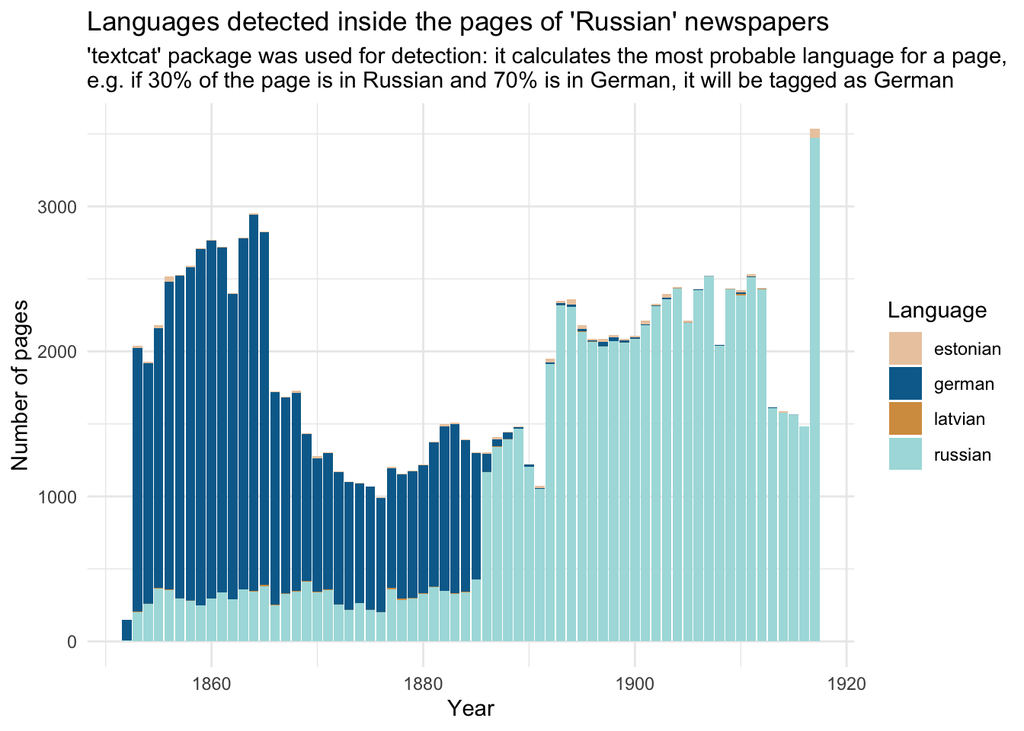

I believe this result is important, since it clearly shows that part of the metadata labels for “Russian” language used in 19-century newspapers should be reassessed: clearly, these are newspapers in German.  
At the same time, I find this language switch from German to Russian in late 1880s very convincing, since the 1880s are known as a Russification period. Curiously enough, it happened very abruptly, so it might be interesting for further researchers to see if the content of newspapers switched from German to Russian changed significantly.

To add more details, the language distribution does not depend on place of publishing, which in overwhelming majority of cases are Riga or Tallinn (Revel):

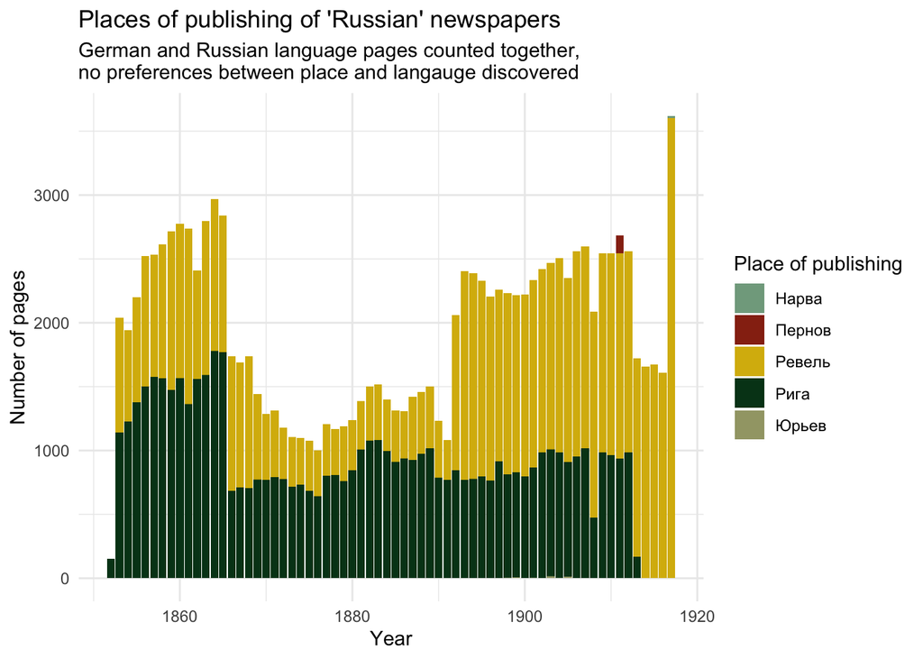

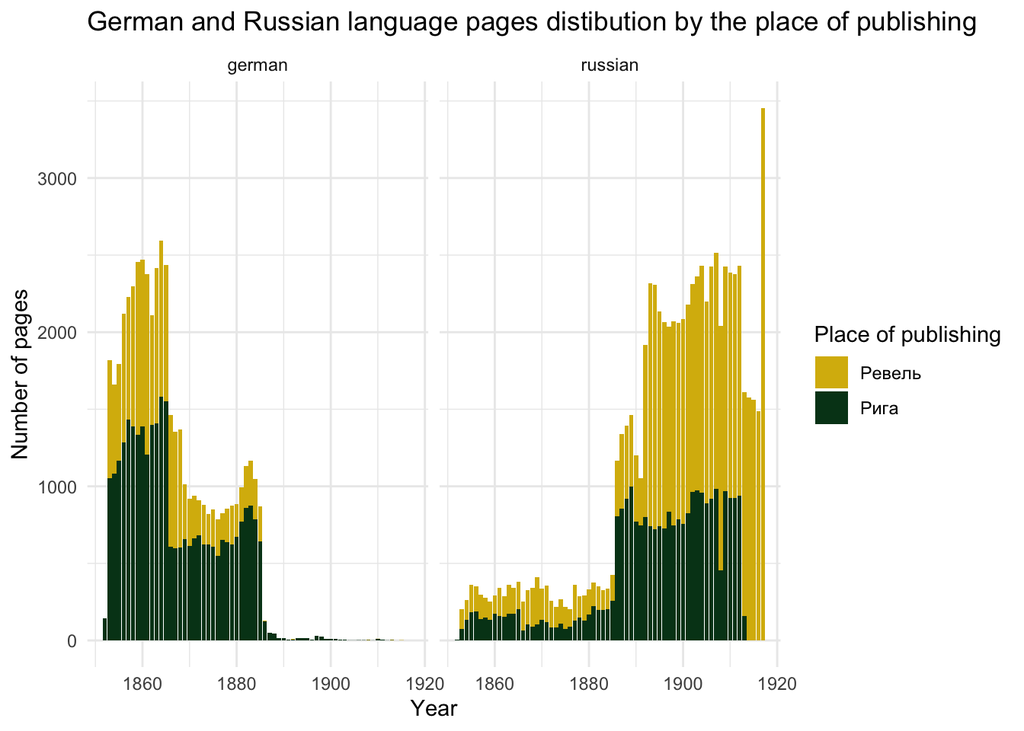

### OCR accuracy & languages

From a technical point of view, the languages (or scripts) hidden behind the “Russian” tag in metadata seems to be important for the OCR quality. If we are to plot OCR accuracy values for decades it may seem that there is a decrease in 1880-s, as one might suppose, led by Russification. This is, however, misleading, because the reason behind the decrease is different OCR accuracy for German and Russian (or Latin and Cyrillic scripts in general). The plot below displays how the OCR quality distributed according to the new language metadata; it is also visible that pages detected as “Ukrainian” have very low OCR quality.  
To sum up, language reassessment on a more granular level (i.e. section) seems important and feasible to be added to respective metadata entries and then grouped to multilingual labels for the language data of entire newspaper titles.

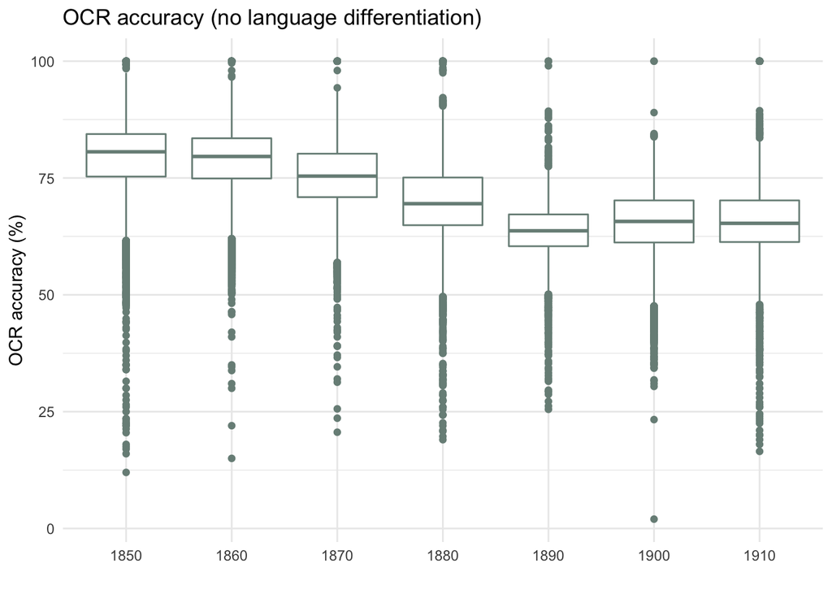

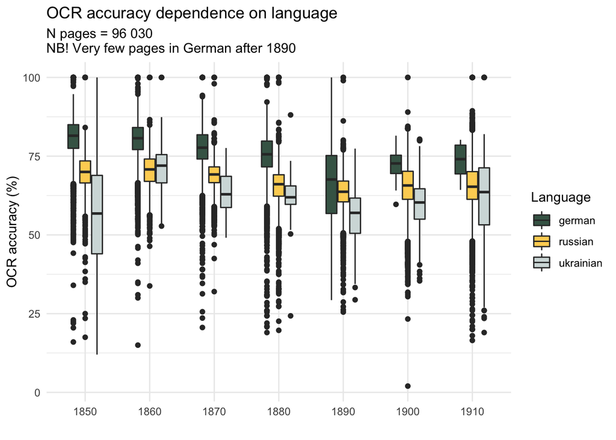

# Language detection based on sections data

*Report update: 10/11/2022*

The part above showed the difference between title-level language metadata and actual languages used in the governmental newspapers in the collection: while the newspapers’ language defined as “Russian”, digitized materials allow to conclude that newspapers used predominantly German as a language of communication until mid-1880s. The analysis was done on the page level, determining the proportion of languages used and labeling each page with most probable language. The results might be yet improved using as input data not the whole pages but newspaper segments or **sections**, where each section will most probably be written in only one language.  
This update of the report aims to demonstrate results from the language detection made on the **section** level. However, as sections division is available at the moment only for the two newspapers, the results below cannot be directly compared to the analysis done on the full corpus (namely, the sections are available only for Estonian and Livonian governorate official newspapers, shortened in the dataset as `ekmteataja` and `livzeitung` respectively).  
The languages of sections were detected with the `textcat` package as in the page-level analysis.  
Ten most common languages for sections are mostly the same as the ones detected on the page level; the probability of error is higher for small sections (in particular, the ones that include less than 20 words).

| language | n_sections | percentage |
| --- | --- | --- |
| russian | 126937 | 56.84 |
| german | 83578 | 37.42 |
| ukrainian | 6257 | 2.80 |
| english | 1495 | 0.67 |
| estonian | 1299 | 0.58 |
| bulgarian | 1078 | 0.48 |
| middle_frisian | 886 | 0.40 |
| rumantsch | 305 | 0.14 |
| latvian | 290 | 0.13 |
| belarus | 276 | 0.12 |

Such unexpected (for Baltic newspapers) languages as English, Bulgarian and Rumantsch appeared to be detection errors for short sections with low OCR quality. Unfortunately, as well as in the case of page input, Ukrainian and Belarus languages are detection errors most probably caused by poor OCR and/or lack of training data for detecting these languages. The examples taken randomly for each of the false-detected language are shown below.

| lang | text |
| --- | --- |
| belarus-windows1251 | ZiüMv-ZlonnW Нар. изд. Я. Верм ана. Для ознакомлешя одна км. высыя. беаалатнв. Сяб.. Фонтанна ?j. |
| bulgarian-iso8859_5 | Став Отправлешя. ц i в: Нааначен1я. накладных^ Время отправления. Отправитель. Получатель. Родъ товара. ВЪсъ. II. Ф. Цвинскъ Модонъ 5043 15 сентября Хаймъ ВалПредъявит. Веревки . . . 5 05 1903 г. лерн… |
| english | ЧАСТЬ ОФФИЦИАЛЬНАЯ. Отделъ местный. Officieller Theil. Locale Abtheilung. |
| ukrainian-koi8_r | П ММЦШ ГЛВЯОП* ТШЮГРАФМ ( Зяьмоигх») посту лиди въ продажу отдЪаышми брошюрами; ОБЯЗАТЕЛЬНЫЙ ПОСТАНОВЛЕНЫ Рижской Городской Дупы. X. О распорядк! на Рижскихъ рынкахг. XX. Для заведений трактирнаго про… |

Nevertheless, `textcat` package output seems to be true for the sections labeled as Latvian or Estonian even for cases when several languages are mixed inside a section, e.g.:

| lang | text |
| --- | --- |
| estonian | Kulutus. Liiwlandi Kubbernemango Wattitsus on Patenti läbbi sest 16. Oktobrist 1862, Nr. 71 ja Liiwlandi Kubbernemango Tseitungi läbbi sest 11. Aprilist 1855, Nr. 42 teada aimud, et ükspäinis Priwati-… |
| latvian | !!Walmeerâ!! Preeksch wifadeem godeem peedahwa grun, tiguwihnu, konjaku. araku, ruviu. likeeruS un wisadus fchehlHinuS no teem wisslaweliateem wihna pagrabcem un spirtus destilaturahm par mehreenu zen… |

Selecting only Russian, German, Estonian and Latvian sections, the distribution of languages in sections is the following:

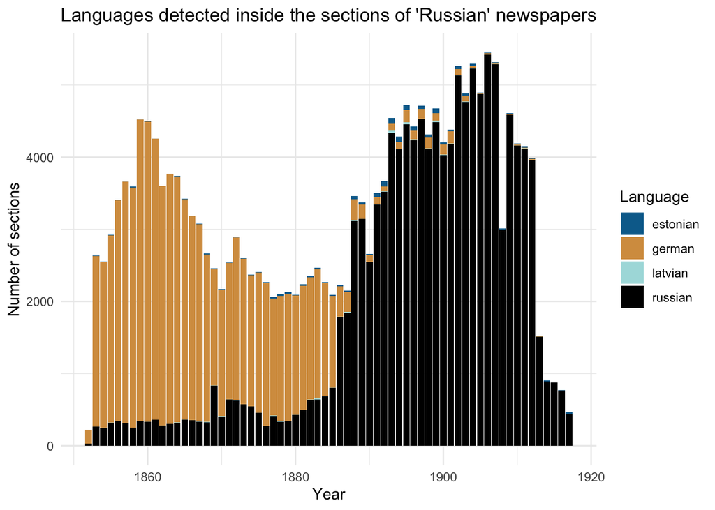

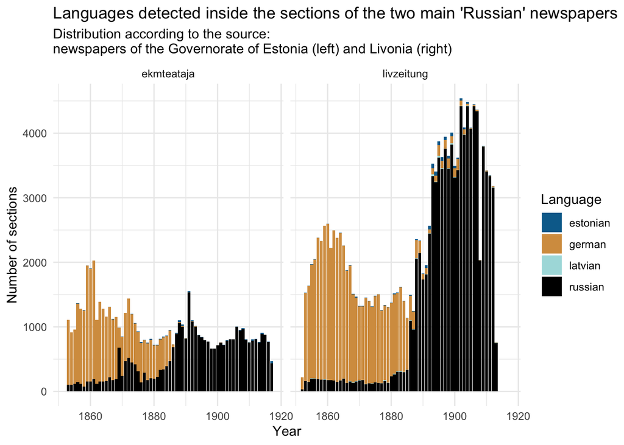

Number of sections and words in each language:

| Language | Newspapter | N sections | N words |
| --- | --- | --- | --- |
| estonian | ekmteataja | 405 | 143706 |
| estonian | livzeitung | 894 | 780308 |
| german | ekmteataja | 28797 | 12644769 |
| german | livzeitung | 54781 | 30316848 |
| latvian | livzeitung | 290 | 180542 |
| russian | ekmteataja | 35204 | 23334143 |
| russian | livzeitung | 91733 | 36699193 |

As sections differ in length, there is a possibility that counting sections (previous plot) might not reflect the actual proportion of languages used in texts of different languages. This assumption can be tested using number of words in each section (`LogicalSectionTextWordCount` in the metadata). The main assumption is that one section was in most cases written in one language (thus the same method seems less applicable to pages). Resulting distribution is very similar to the section count showed above:

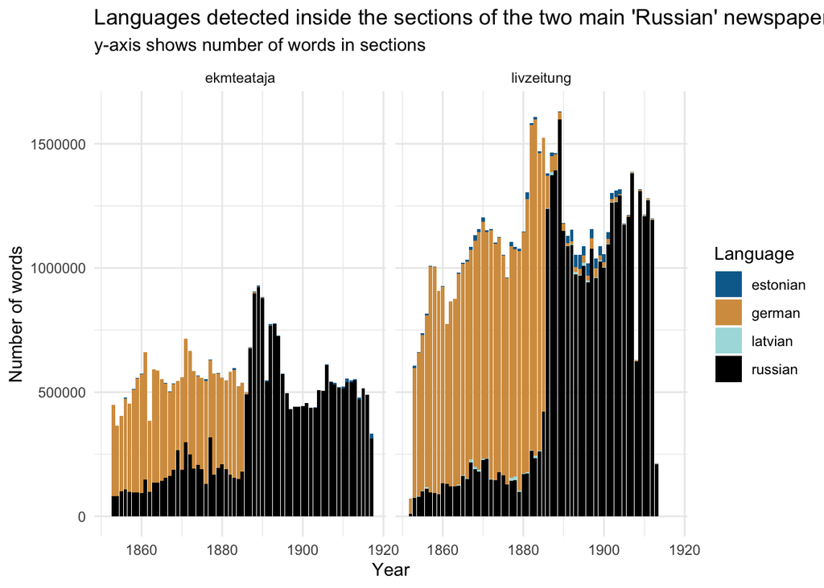

To compare the results with the page-level language detection, it is possible to filter only `ekmteataja` and `livzeitung` from the results gathered previously (stored in `data/01_pages_meta_rus_lang.csv`). The main shift from German to Russian and the proportion overall seem roughly same as in the case of sections.

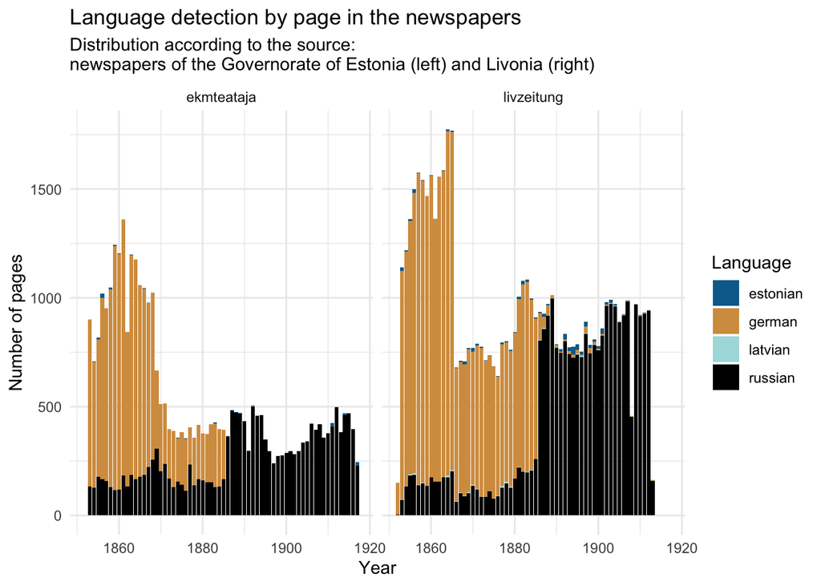

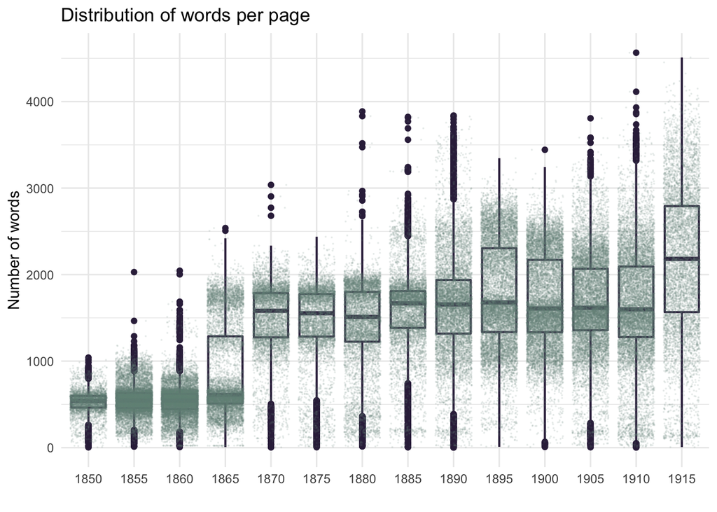

Section-based analysis thus showed more reliable results, reflecting not only the language use in the newspapers, but also some physical properties of the newspapers, such as page or font size changes over time. The plot shows how number of words per page changed in the second half of the 1860s and then remained more or less stable, so that higher number of pages in German in the 1850s and 1860s counter intuitively witness smaller amount of text per page.

Additionally, the OCR accuracy dependence on the language can be checked on the level of sections.

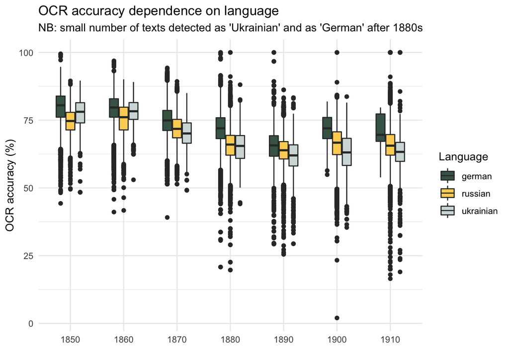